# 21. Linear Probes and Concepts

- motivating application
- linear probes
- training concept vectors
- probes vs. concepts

### Learning Outcomes

- Describe the theoretical foundation of post-hoc explanation methods like SHAP and linear probes values and apply them to realistic case studies with appropriate validation checks
- Analyze large-scale foundation models using methods like sparse autoencoders and describe their relevance to problems of model control and AI-driven design.
- Within a specific application context, evaluate the trade-offs associated with competing interpretable machine learning techniques.

### Readings

Alain, G., & Bengio, Y. (2017). Understanding intermediate layers using linear classifier probes. OpenReview. https://openreview.net/forum?id=ryF7rTqgl

Schmalwasser, L., Penzel, N., Denzler, J., & Niebling, J. (2025). FastCAV: Efficient computation of concept activation vectors for explaining deep neural networks. In Proceedings of the 42nd International Conference on Machine Learning. https://openreview.net/forum?id=kRmfzTfIGe

### Motivating Case Study

Predict livability from aerial imagery.

- Can we trust what the model learns?
- Will it generalize?

[figure not shown]

### Statistical Formulation

**Data**. 51,781 grid cells (100m²) in Netherlands. Each has livability score $y \in \mathbf{R}$ and 500×500px aerial image $x$.

**Supplemental**. FLAIR land use labels from French National Institute.

**Goal**. Which visual concepts does $f(x;\theta)$ use to predict $y$?

**Concept labels** $c \in \{1,\ldots,K\}$ from auxiliary dataset.

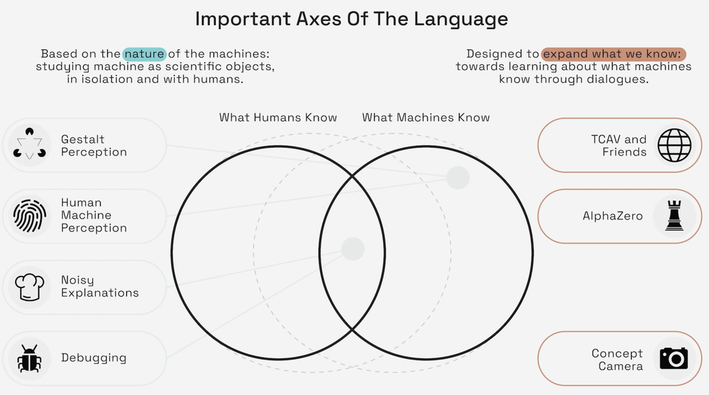

## Linear Probes

### Notation

$h_l(x)$ — activation vector at layer $l$

$p_l(h) = \text{softmax}(W_l h + b_l)$ — linear classifier predicting $y$ from $h_l$

**Diode constraint**. $\frac{\partial \mathcal{L}}{\partial \theta} = 0$ (probe training doesn’t affect base model)

### Estimation

Minimize empirical risk on hidden representations:
$$\min_{W_l, b_l} \sum_{i=1}^N \mathcal{L}(p_l(h_l(x_i)), y_i)$$

**Validation**. Test on held-out data to ensure genuine learned features, not memorization.

**Information vs. Accessibility**. Total mutual information $I(X; h_l)$ may decrease with depth (Data Processing Inequality), but *linear accessibility* of task-relevant information typically increases.

### Cartoon

[figure not shown]

Early layers: generic features (edges). Deep layers: task-specific, linearly separable.

### Outputs

- Layer-wise error $\to$ where model “solves” task
- Training dynamics $\to$ epochs until layer becomes useful
- Representational capacity $\to$ signal preserved at each bottleneck

### Example: Skip Connections

**Bug detection via probes**. Skip connection from layer 1→64 rendered layers 2–63 “dead” (flat error rates).

[figure not shown]

### Exercise: Linear Probe Pseudocode

Write the pseudocode to extract activations and train a probe for a single layer.

## Concept Activation Vectors

### Notation

**CAV**. $v_c^l \in \mathbf{R}^{d_l}$ — direction of concept $c$ in layer $l$

**Concept Sensitivity**. Directional derivative of class $k$ logit along concept vector:
$$S_{c,k}(x) = \nabla_{h} f_k(h_l(x)) \cdot v_c^l$$

**TCAV Score**. $T_{c,k} = \frac{|\{x \in X_k : S_{c,k}(x) > 0\}|}{|X_k|}$

Fraction of class-$k$ images where concept $c$ increases model confidence.

**Step 1**. Define concept images $x_n \in D_c$ (positive set). Construct control pool $x_n' \in N$ (negative set, random images).

Concept: “stripes”

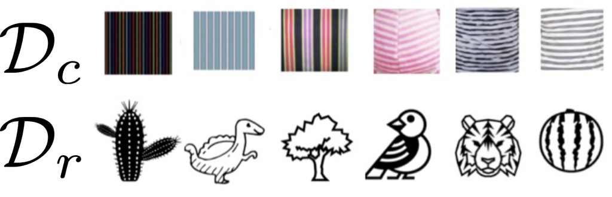

**Step 2**. Find direction $v_c^l$ that best separates $h_l(D_c)$ from $h_l(N)$ in activation space.

**Standard**. Train linear SVM. CAV is the normal vector to decision boundary.

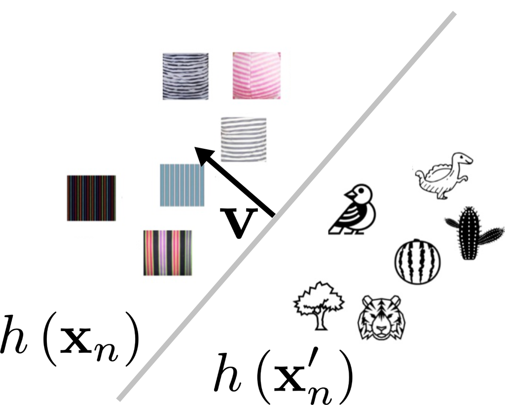

**Step 3**. Compute sensitivity of model’s prediction to this direction.

$$\text{Sensitivity} = \text{Model Gradient} \cdot \text{Concept Direction}$$

Global explanation: “To what extent does concept ‘stripes’ contribute to the model’s definition of ‘zebra’?”

$\nabla y_k(h(x))$ is the steepest ascent direction for class $k$’s logit.

[figure not shown]

### Alternative Step 2: FastCAV

$v_{\text{FastCAV}} = \frac{\bar{h}_c - \bar{h}_r}{\|\bar{h}_c - \bar{h}_r\|}$

Equivalent to SVM under isotropic covariance ($\Sigma = \sigma^2 I$).

Leads to 46.4× average speedup.

### Testing for Significance

1. Generate CAVs from multiple random negative sets
2. Build null distribution of TCAV scores
3. Two-sided t-test: is actual concept significant vs. random baseline?

More details in next lecture.

## Probes vs. Concepts

### Similarities

- Post-hoc (frozen model)
- Linear accessibility assumption
- Activation-based ($h_l(x)$)

### Differences

**Probes-specific**

- Align using model’s task labels ($y$)
- Final output is probe accuracy
- Goal is to measure the available task-specific information

**Concepts-specific**

- Align using human semantics ($c$)
- Final output is TCAV sensitivity score
- Goal is to model reasoning with human-understandable features

### Exercise: Agency vs. Automation